# 05 - Data Manipulation Two Answers

# Introduction and Setup

For these exercises, we will look at the core concepts from this lesson.

For these exercises we’ll a simulated data set I created in the **data_generation** folder which is saved to the inputs folder as `sim_data.RData`. This data was saved as a tibble in the RData file, so we just use `load()` to open this data into R.

```r
# load libraries
library(tidyverse)
library(lubridate)

# load data
load("inputs/sim_data.RData")
```

This data set looks at reaction times in spotting a target when people have had caffeine or not, and when they respond with their dominant or non-dominant hand. This data set is entirely made up, so we can’t be sure how realistic these results are.

First, you should take a look at your data to understand it. A simple first step is to see what the data table itself looks like.

```r
glimpse(data)
```

```
Rows: 100
Columns: 5
$ subject  <int> 1, 2, 3, 4, 5, 6, 7, 8, 9, 10, 11, 12, 13, 14, 15, 16, 17, 18,…
$ age      <int> 34, 56, 23, 53, 44, 21, 55, 47, 29, 31, 35, 56, 34, 62, 56, 21…
$ caffeine <fct> no, no, no, no, no, no, no, no, no, no, no, no, no, no, no, no…
$ response <fct> non-dominant, non-dominant, non-dominant, non-dominant, non-do…
$ DV       <dbl> 398.6627, 396.3824, 400.1234, 401.9182, 397.6403, 398.8435, 39…
```

After this, we should make a more detailed plot to understand the general trends in the data.

## Question 1

Make a plot of your data which looks at the relationship beween **caffeine** and **DV**. Split this plot into two to show the differences across the two response conditions.

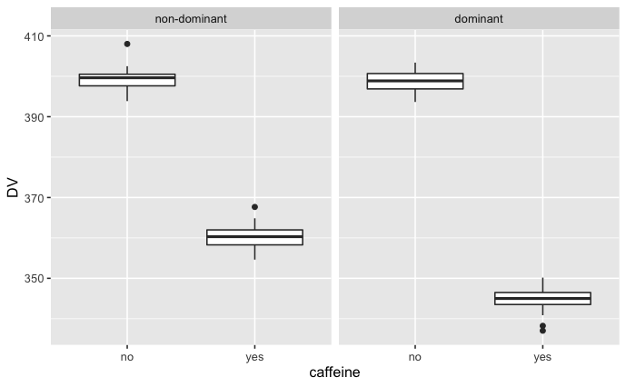

```r
ggplot(data = data, mapping = aes(x = caffeine, y = DV)) +
  geom_boxplot() +
  facet_wrap(~ response)
```

What are the general trends in the data?

**Answer**: There seems to be a main effect of caffeine, which is more pronounced if people respond with their dominant hand versus their non-dominant hand.

## Question 2

Subset your data to remove the ages from the data set.

```r
data %>% select(-age)
```

| subject | caffeine | response | DV |
| --- | --- | --- | --- |
| 1 | no | non-dominant | 398.6627 |
| 2 | no | non-dominant | 396.3824 |
| 3 | no | non-dominant | 400.1234 |
| 4 | no | non-dominant | 401.9182 |
| 5 | no | non-dominant | 397.6403 |
| 6 | no | non-dominant | 398.8435 |
| 7 | no | non-dominant | 398.5724 |
| 8 | no | non-dominant | 402.1593 |
| 9 | no | non-dominant | 399.9445 |
| 10 | no | non-dominant | 395.8806 |

[output cut: 90 more lines]

## Question 3

Rename the **DV** column to something more informative, like **reaction_time**

```r
data %>% rename(reaction_time = DV)
```

| subject | age | caffeine | response | reaction_time |
| --- | --- | --- | --- | --- |
| 1 | 34 | no | non-dominant | 398.6627 |
| 2 | 56 | no | non-dominant | 396.3824 |
| 3 | 23 | no | non-dominant | 400.1234 |
| 4 | 53 | no | non-dominant | 401.9182 |
| 5 | 44 | no | non-dominant | 397.6403 |
| 6 | 21 | no | non-dominant | 398.8435 |
| 7 | 55 | no | non-dominant | 398.5724 |
| 8 | 47 | no | non-dominant | 402.1593 |
| 9 | 29 | no | non-dominant | 399.9445 |
| 10 | 31 | no | non-dominant | 395.8806 |

[output cut: 90 more lines]

## Question 4

What if we care about differences in the ages? Let’s assume we have a prediction that caffeine only has an effect on those above 30 years of age. Subset your data to just those above 30 years of age.

```r
data %>% filter(age > 30)
```

| subject | age | caffeine | response | DV |
| --- | --- | --- | --- | --- |
| 1 | 34 | no | non-dominant | 398.6627 |
| 2 | 56 | no | non-dominant | 396.3824 |
| 4 | 53 | no | non-dominant | 401.9182 |
| 5 | 44 | no | non-dominant | 397.6403 |
| 7 | 55 | no | non-dominant | 398.5724 |
| 8 | 47 | no | non-dominant | 402.1593 |
| 10 | 31 | no | non-dominant | 395.8806 |
| 11 | 35 | no | non-dominant | 397.0527 |
| 12 | 56 | no | non-dominant | 398.3365 |
| 13 | 34 | no | non-dominant | 400.3641 |

[output cut: 63 more lines]

## Question 5

Rearrange the data set by age, starting from the **highest** age.

```r
data %>% arrange(desc(age))
```

| subject | age | caffeine | response | DV |
| --- | --- | --- | --- | --- |
| 41 | 68 | no | dominant | 397.4481 |
| 34 | 67 | no | dominant | 397.6045 |
| 64 | 66 | yes | non-dominant | 363.5883 |
| 68 | 65 | yes | non-dominant | 364.8576 |
| 91 | 65 | yes | dominant | 349.9146 |
| 66 | 64 | yes | non-dominant | 359.1170 |
| 83 | 64 | yes | dominant | 342.9256 |
| 59 | 63 | yes | non-dominant | 367.6620 |
| 14 | 62 | no | non-dominant | 399.6374 |
| 75 | 61 | yes | non-dominant | 359.5220 |

[output cut: 90 more lines]

## Question 6

Calculate mean centered scores for each subject and add these to a new column called **DV_c** (DV, centered). The formula for this is `subjects_score - mean(all_scores)`. Can you work out what the mean should (approximately) be?

```r
data %>% mutate(DV_c = DV - mean(DV))
```

| subject | age | caffeine | response | DV | DV_c |
| --- | --- | --- | --- | --- | --- |
| 1 | 34 | no | non-dominant | 398.6627 | 22.863528 |
| 2 | 56 | no | non-dominant | 396.3824 | 20.583293 |
| 3 | 23 | no | non-dominant | 400.1234 | 24.324241 |
| 4 | 53 | no | non-dominant | 401.9182 | 26.119028 |
| 5 | 44 | no | non-dominant | 397.6403 | 21.841199 |
| 6 | 21 | no | non-dominant | 398.8435 | 23.044394 |
| 7 | 55 | no | non-dominant | 398.5724 | 22.773259 |
| 8 | 47 | no | non-dominant | 402.1593 | 26.360114 |
| 9 | 29 | no | non-dominant | 399.9445 | 24.145345 |
| 10 | 31 | no | non-dominant | 395.8806 | 20.081509 |

[output cut: 90 more lines]

**Answer**: The mean of the mean centered scores should be around 0, as the centred scores tell us far away each participant was from the mean.

## Question 7

Let’s assume we have a prediction that response times should be slower above 30 years of age. Create a new column, **age_group** that puts participants into two groups **30_or_under**, and **above_30**.

*Hint*: Look up the `ifelse()` function using `?ifelse()` to see how you can use logical operations to achieve this.

```r
data %>% mutate(age_group = ifelse(age <= 30, "30_or_under", "above_30"))
```

| subject | age | caffeine | response | DV | age_group |
| --- | --- | --- | --- | --- | --- |
| 1 | 34 | no | non-dominant | 398.6627 | above_30 |
| 2 | 56 | no | non-dominant | 396.3824 | above_30 |
| 3 | 23 | no | non-dominant | 400.1234 | 30_or_under |
| 4 | 53 | no | non-dominant | 401.9182 | above_30 |
| 5 | 44 | no | non-dominant | 397.6403 | above_30 |
| 6 | 21 | no | non-dominant | 398.8435 | 30_or_under |
| 7 | 55 | no | non-dominant | 398.5724 | above_30 |
| 8 | 47 | no | non-dominant | 402.1593 | above_30 |
| 9 | 29 | no | non-dominant | 399.9445 | 30_or_under |
| 10 | 31 | no | non-dominant | 395.8806 | above_30 |

[output cut: 90 more lines]

## Question 8

Calculate the mean, standard deviation, and number of observations for each group.

```r
data %>%
  group_by(caffeine, response) %>%
  summarise(mean_DV = mean(DV),
            sd_DV = sd(DV),
            n = n()
            )
```

| caffeine | response | mean_DV | sd_DV | n |
| --- | --- | --- | --- | --- |
| no | non-dominant | 399.3420 | 2.850355 | 25 |
| no | dominant | 398.7063 | 2.781825 | 25 |
| yes | non-dominant | 360.2913 | 3.121749 | 25 |
| yes | dominant | 344.8570 | 3.259371 | 25 |

## Question 9

```r
data %>%
  group_by(caffeine, response) %>%
  filter(rank(age) >= 3) %>%
  summarise(mean_DV = mean(DV),
            sd_DV = sd(DV),
            n = n()
            )
```

| caffeine | response | mean_DV | sd_DV | n |
| --- | --- | --- | --- | --- |
| no | non-dominant | 399.2090 | 2.991240 | 22 |
| no | dominant | 398.6372 | 2.854392 | 23 |
| yes | non-dominant | 360.4608 | 3.238810 | 22 |
| yes | dominant | 344.7720 | 3.317704 | 23 |

## Question 10

Take the data and do this all together:

```r
data %>%
  rename(response_time = DV) %>%
  filter(age < 60) %>%
  mutate(condition = paste(caffeine, response, sep = "_")) %>%
  select(subject, age, condition, response_time) %>%
  group_by(condition) %>%
  summarise(mean_RT = mean(response_time),
            sd = sd(response_time),
            n = n()
            )
```

| condition | mean_RT | sd | n |
| --- | --- | --- | --- |
| no_dominant | 398.7545 | 2.937370 | 22 |
| no_non-dominant | 399.3297 | 2.910981 | 24 |
| yes_dominant | 345.0158 | 2.938052 | 22 |
| yes_non-dominant | 359.6268 | 2.685619 | 20 |

## Question 11

Was there any point in us combining the two factors into a single condition column? Do the same process above without making a summary of the data. Feed this data into a boxplot, with condition on the x-axis, and response_time on the y-axis.

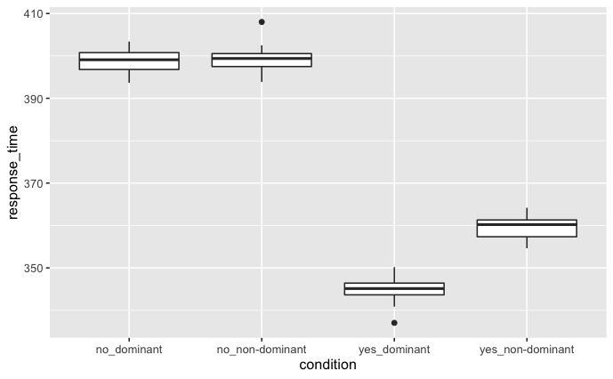

```r
data %>%
  rename(response_time = DV) %>%
  filter(age < 60) %>%
  mutate(condition = paste(caffeine, response, sep = "_")) %>%
  select(subject, age, condition, response_time) %>%
  ggplot(mapping = aes(x = condition, y = response_time)) +
    geom_boxplot()
```